# 03_Visualization2

Tobias Gerstenberg

1/11/2019

## Student feedback

> It would be helpful if you could pause at your code a little more once we have made our practice plots (for future lectures). Also we covered a lot of types of plots which was good, but it would’ve helped to focus on the most commonly used ones and ways to edit and customize that - we can explore the other types at home. Thank you!

> I think the lecture about class 3 is way too fast for beginners to follow. I really appreciate the lecture notes that you have prepared and it is very informative. However, if we can save time at the beginning of the lecture (not to talk about the poll results , and you can simply email us the results), then perhaps we will have much more time to talk about the lecture. Another thing that I will appreciate is that if you can talk about more how to interpret a violin/joy plots, this will be awesome, as traditional stats class did not talk about these!

> Like the diversity of graphs we generated

> Great overall. Possibly too much material planned for 1 class. The exercises are super helpful. **Note that our lines in the code don’t match yours once we fill in an exercise, so direct references to lines as poiters to where we are don’t always work.**

> I thought it was a good class! I think mastering ggplot takes a lot of time and it’s kind of endless skillset, so it just takes a ton of practice and iteration

> It’s nice to have the in-class Rmd files as far in advance as possible. I like to work through them before class so I can keep up.

|  | response |
| --- | --- |
| 1 | I like the music. And the hammer. I felt we went too quickly over the last bit of the visualization 2 file, which is probably the content that is most unfamiliar to most people. For example, I'm still… |
| 2 | It would be helpful if you could pause at your code a little more once we have made our practice plots (for future lectures). Also we covered a lot of types of plots which was good, but it would've he… |
| 3 | I think the lecture about class 3 is way too fast for beginners to follow. I really appreciate the lecture notes that you have prepared and it is very informative. However, if we can save time at the … |
| 4 | Good to push my knowledge of R - a "reproduce this plot" works well to make me think deeper about plots - instead of changing what I want to visualize because of my knowledge I expand my knowledge to … |
| 5 | Great overall. Possibly too much material planned for 1 class. The exercises are super helpful. Note that our lines in the code don't match yours once we fill in an exercise, so direct references to l… |
| 6 | The music. |
| 7 | Pace was a tiny bit fast, but I guess that's fine since we can always go back to the RMarkdown files and go through the exercises on our own at home. I love how much attention you give to the feedback… |
| 8 | Great class! Maybe a note to the lines in the R Markdown files: When exercises are included or you show other things in between, the lines get messed up which is why I often need longer time to actual… |
| 9 | Explained earlier |
| 10 | Learned a lot of new tricks about ggplot, which is helpful. This class (so far) is perfect after Mike's 251, and I'm glad we're not going any slower. For section, maybe we could do some more of the ha… |

[output cut: 25 more lines]

### PollEverywhere results

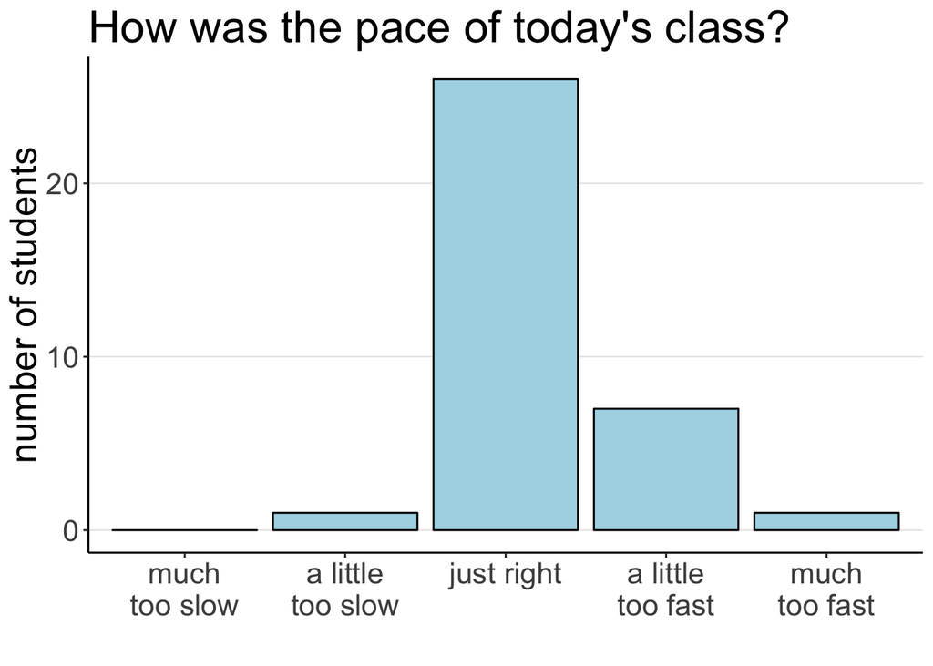

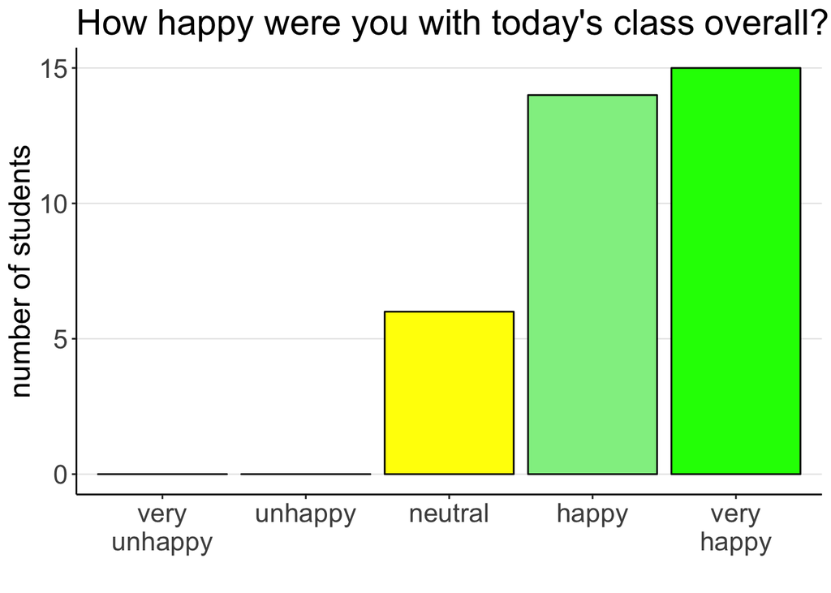

## What to do next time

- have bookmarks that allow me to go to the different sections (line numbers get out of sync)
- maybe focus on fewer plots (the most used ones), and discuss these in more depth
- make materials available as early as possible (maybe use github in the future so I can easily tweak things)
- keep the music!